# npdb_work

Tiasia Saunders

2025-08-06

## NPDB Data Analysis

#### The NPDB is the National Practitioner Data Bank, which is a repository of reports on healthcare practitioners, including adverse actions and medical malpractice payments.

| Feature | Adverse Action Reports (AAR) | Medical Malpractice Payment Reports (MMPR) |
| --- | --- | --- |
| **Type of event** | Disciplinary or administrative action | Malpractice payment |
| **Cause** | Misconduct, incompetence, or policy violations | Alleged negligence resulting in patient harm |
| **Filed by** | Licensing boards, hospitals, agencies, etc. | Malpractice insurers or self-insured entities |
| **Involves payment?** | No | Yes |
| **Indicates fault?** | Possibly (based on formal disciplinary action) | Not necessarily (payment ≠ admission of fault) |

##### Analysis Purpose: Through this analysis, I will explore the NPDB data to identify trends and patterns in adverse actions and medical malpractice reports across different states.

##### Data Limitations:

- For this analysis, I downloaded two datasets from the NPDB website:
- The first dataset contains state-level data on adverse actions and medical malpractice reports from year 2020- March 31st, 2025.
- The second dataset contains yearly reports from 2015 to March 2025 of adverse actions and medical malpractice reports combined by state.

```r
library(tidyverse)
library(tidycensus)
library(dplyr)
library(janitor)
```

```r
library(ggplot2)
library(maps)
library(dplyr)
```

```r
## loading data
 npdb_state_data <- read_csv("npdb_state_record.csv") |>
  clean_names()
 yearly_reports_data <- read_csv("yearly_reports.csv") |>
  clean_names()
```

##### Questions:

1. What are the top 5 states with the most adverse action reports?
2. What are the top 5 states with the most medical malpractice report?
3. Do a timeline of the reports for the top states?
4. What are the 5 top states with the least amount of reports as a whole (look at yearly_reports_data)?

```r
top_adverse_states <- npdb_state_data |>
  select(state, adverse_action_report) |>
  arrange(desc(adverse_action_report)) |>
  slice(2:6)
print(top_adverse_states)
```

```
## # A tibble: 5 × 2
##   state      adverse_action_report
##   <chr>                      <dbl>
## 1 California                 19981
## 2 Texas                      19752
## 3 Florida                    12126
## 4 Ohio                       11867
## 5 Michigan                   10275
```

- The top 5 states that have the highest AARs are the following: California, Texas, Florida, Ohio and Michigan

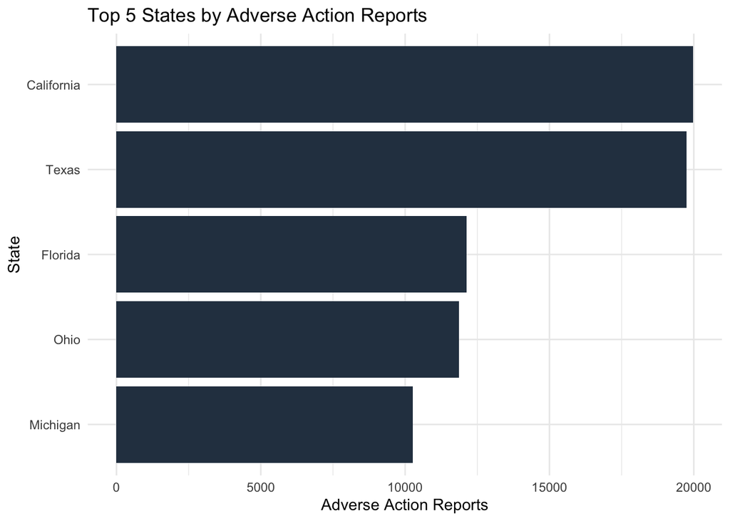

```r
top_adverse_states |>
ggplot(aes(x = reorder(state, adverse_action_report),
             y = adverse_action_report)) +
  geom_col(fill = "#2c3e50") +
  coord_flip() +
  labs(
    title = "Top 5 States by Adverse Action Reports",
    x = "State",
    y = "Adverse Action Reports"
  ) +
  theme_minimal()
```

- The top 5 states with the most AARs are the following: California, Texas, Florida, Ohio, and Michigan

```r
top_malpractice_states <- npdb_state_data |>
  select(state, medical_malpractice_payment_report) |>
  arrange(desc(medical_malpractice_payment_report)) |>
  slice(2:6)

print(top_malpractice_states)
```

```
## # A tibble: 5 × 2
##   state        medical_malpractice_payment_report
##   <chr>                                     <dbl>
## 1 New York                                   6381
## 2 Florida                                    5915
## 3 California                                 5160
## 4 Pennsylvania                               4171
## 5 Texas                                      2878
```

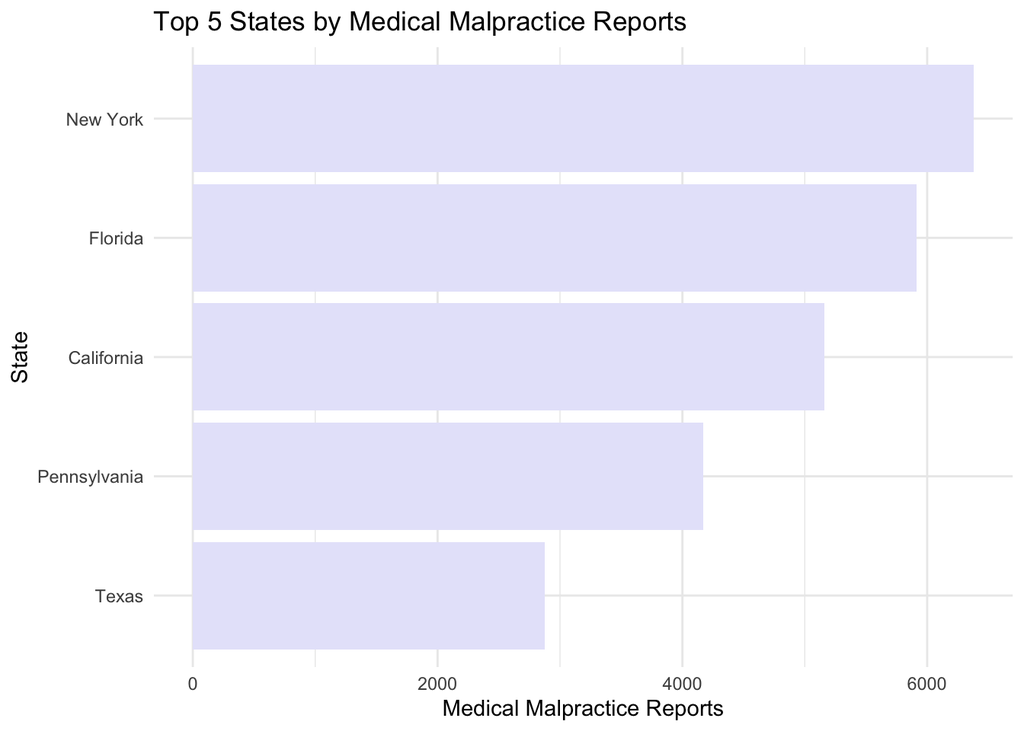

```r
top_malpractice_states |>
ggplot(aes(x = reorder(state, medical_malpractice_payment_report),
             y = medical_malpractice_payment_report)) +
  geom_col(fill = "lavender") +
  coord_flip() +
  labs(
    title = "Top 5 States by Medical Malpractice Reports",
    x = "State",
    y = "Medical Malpractice Reports"
  ) +
  theme_minimal()
```

- The top 5 states that have the highest MMPRs are the following: New York, Florida, California, Pennsylvania and Texas
- The states that occur on both lists are the following: California, Texas, and Florida

```r
top_states_combined <- npdb_state_data |>
  select(state, total) |>
  arrange(desc(total)) |>
  slice(2:6)
print(top_states_combined)
```

```
## # A tibble: 5 × 2
##   state      total
##   <chr>      <dbl>
## 1 California 25141
## 2 Texas      22630
## 3 Florida    18041
## 4 Ohio       12966
## 5 Michigan   11849
```

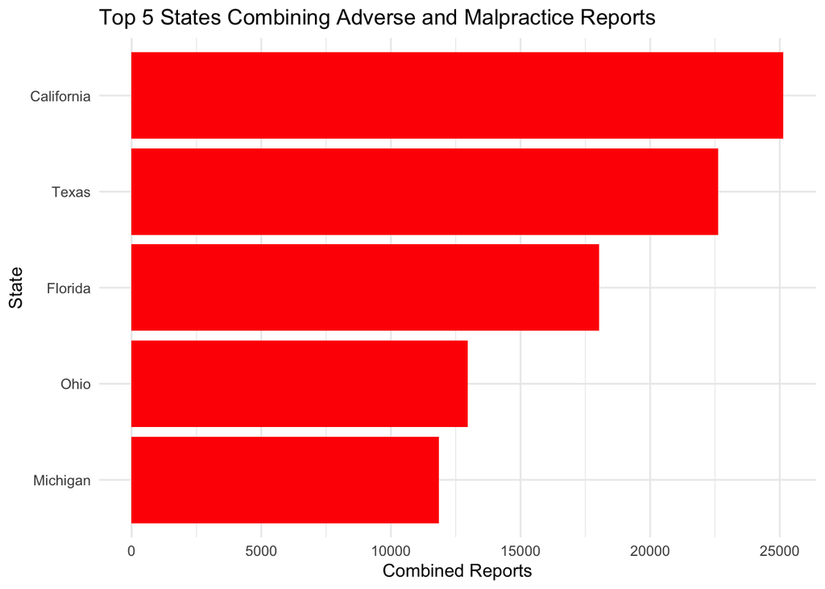

```r
top_states_combined|>
ggplot(aes(x = reorder(state,total),
             y = total)) +
  geom_col(fill = "red") +
  coord_flip() +
  labs(
    title = "Top 5 States Combining Adverse and Malpractice Reports",
    x = "State",
    y = "Combined Reports"
  ) +
  theme_minimal()
```

- The top 5 states with the most AARs and MMPRs

```r
least_adverse_states <- npdb_state_data |>
  select(state, adverse_action_report) |>
  arrange(adverse_action_report) |>
  slice(3:7) #using slice 3 because the first two options are other territories and armed forces
```

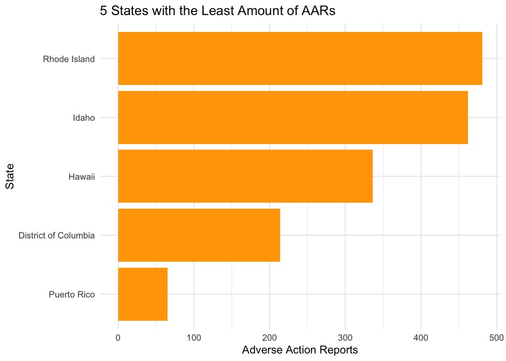

```r
least_adverse_states |>
  ggplot(aes(x = reorder(state, adverse_action_report),
                   y = adverse_action_report)) +
    geom_col(fill = "orange") +
    coord_flip() +
    labs(
      title = "5 States with the Least Amount of AARs",
      x = "State",
      y = "Adverse Action Reports"
    ) +
  theme_minimal()
```

- The 5 states with the least amount of AARs are the following: Rhode Island, Idaho, Hawaii, District of Columbia and Puerto Rico

```r
least_malpractice_states <- npdb_state_data |>
  select(state, medical_malpractice_payment_report) |>
  arrange(medical_malpractice_payment_report) |>
  slice(3:7) #sliced at 3 because the first two options are other territories and armed foces
```

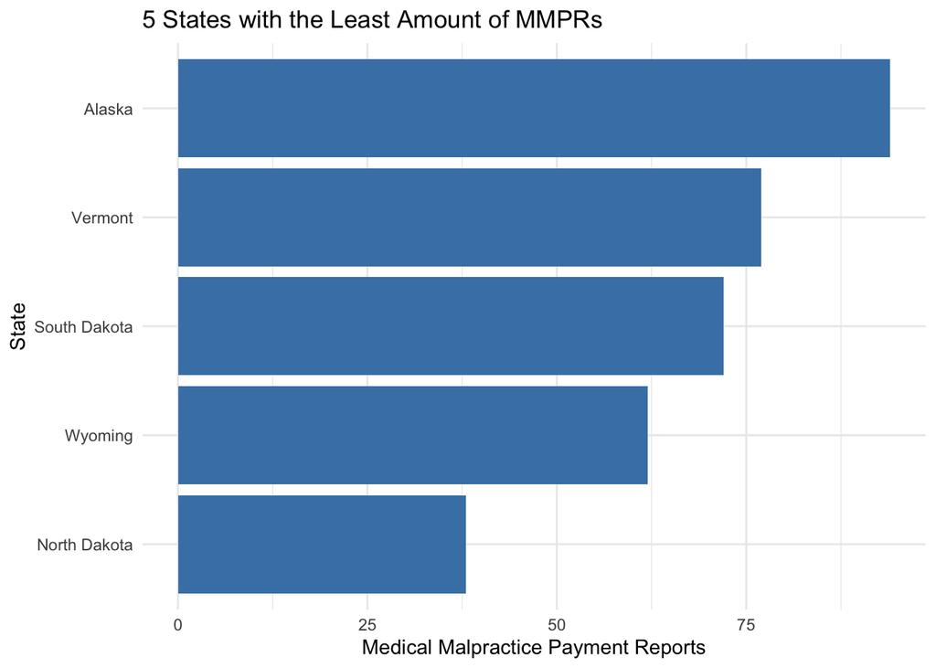

```r
least_malpractice_states |>
  ggplot(aes(x = reorder(state, medical_malpractice_payment_report),
                   y = medical_malpractice_payment_report)) +
    geom_col(fill = "steelblue") +
    coord_flip() +
    labs(
      title = "5 States with the Least Amount of MMPRs",
      x = "State",
      y = "Medical Malpractice Payment Reports"
    ) +
  theme_minimal()
```

- The 5 states with the least amount of MMPRs are the following: Alaska, Vermont, South Dakota, Wyoming, North Dakota

```r
least_combined_reports_states <- npdb_state_data |>
select(state, total) |>
  arrange(total) |>
  slice(3:7) #using slice 3 because the first two options are other territories and armed forces
print(least_combined_reports_states)
```

```
## # A tibble: 5 × 2
##   state                total
##   <chr>                <dbl>
## 1 District of Columbia   319
## 2 Hawaii                 540
## 3 South Dakota           649
## 4 Vermont                661
## 5 Idaho                  675
```

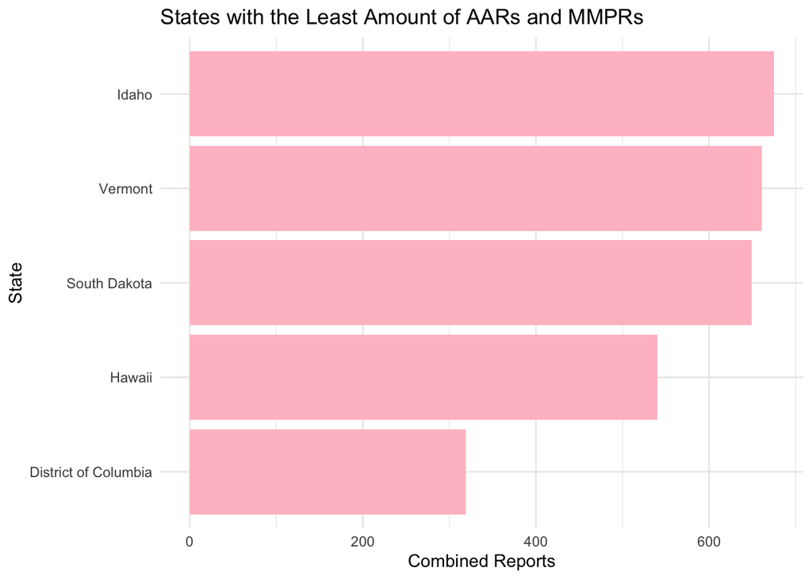

```r
least_combined_reports_states |>
ggplot(aes(x = reorder(state,total),
             y = total)) +
  geom_col(fill = "pink") +
  coord_flip() +
  labs(
    title = "States with the Least Amount of AARs and MMPRs",
    x = "State",
    y = "Combined Reports"
  ) +
  theme_minimal()
```

- The 5 states with the least amount of combined reports are the following: District of Columbia, Hawaii, South Dakota, Vermont and Idaho

```r
least_states <- yearly_reports_data |>
  filter(state %in% c("Idaho", "Vermont", "South Dakota", "Hawaii", "District of Columbia")) |>
  select(-total)

least_states <- least_states |>
  pivot_longer (
    cols = starts_with("year_"),
    names_to = "Year",
    values_to = "Count"
  ) |>
  mutate(
    Year = as.numeric(str_remove(Year, "year_")))
```

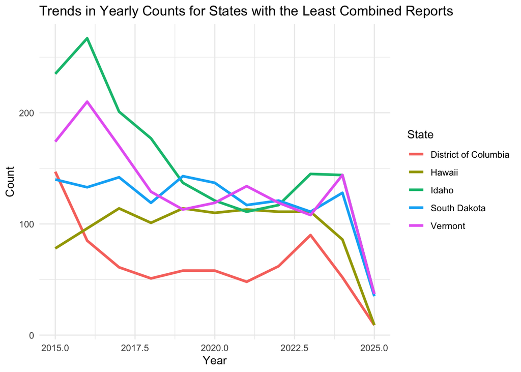

```r
ggplot(least_states, aes(x = Year, y = Count, color = state)) +
  geom_line(size = 1.2) +
  labs(
    title = "Trends in Yearly Counts for States with the Least Combined Reports",
    x = "Year",
    y = "Count",
    color = "State"
  ) +
  theme_minimal()
```

```r
top_states <- yearly_reports_data |>
  filter(state %in% c("California", "Florida", "Texas")) |>
  select(-total)

top_states <- top_states |>
  pivot_longer(
    cols = starts_with("year_"),
    names_to = "Year",
    values_to = "Count"
  ) |>
  mutate(
    Year = as.numeric(str_remove(Year, "year_")))
```

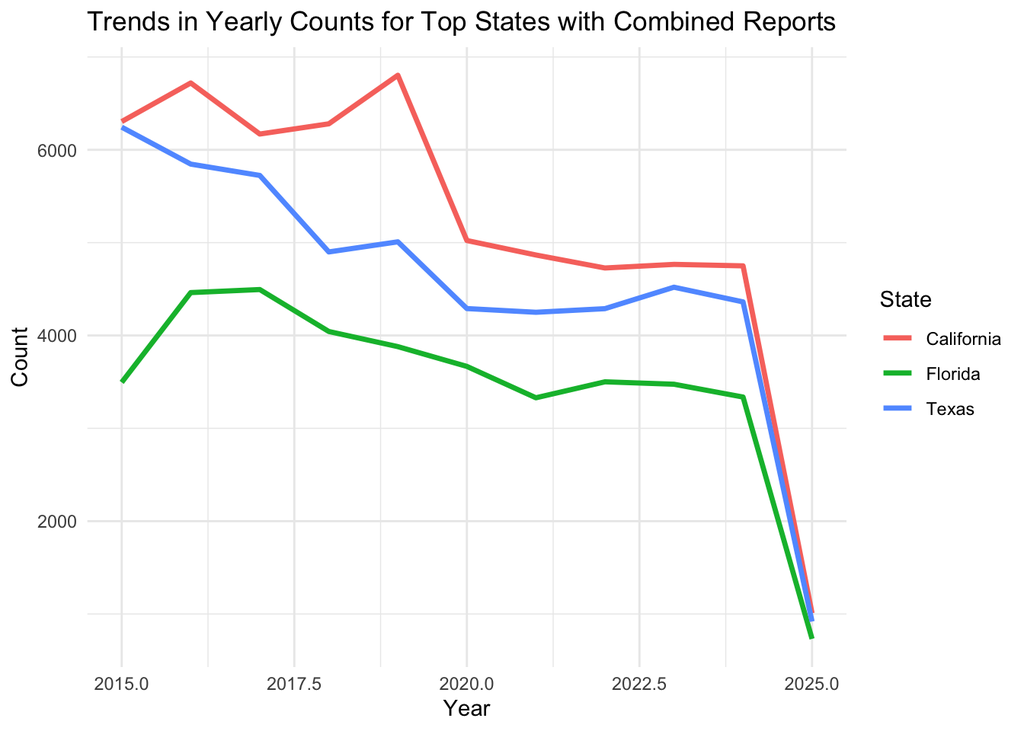

```r
ggplot(top_states, aes(x = Year, y = Count, color = state)) +
  geom_line(size = 1.2) +
  labs(
    title = "Trends in Yearly Counts for Top States with Combined Reports",
    x = "Year",
    y = "Count",
    color = "State"
  ) +
  theme_minimal()
```

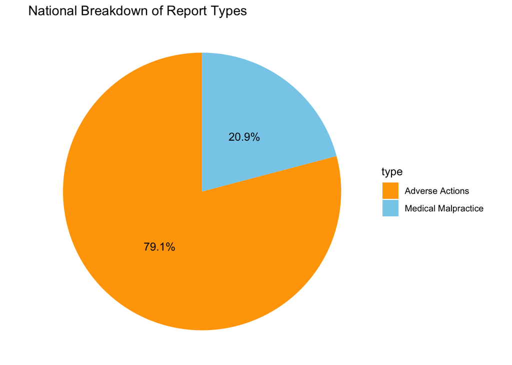

```r
# Create data frame
national_percentage <- data.frame(
  type = c("Adverse Actions", "Medical Malpractice"),
  count = c(209032, 55194)
)

# Add percentage column
national_percentage$percent <- round(national_percentage$count / sum(national_percentage$count) * 100, 1)

# Plot with ggplot2
ggplot(national_percentage, aes(x = "", y = count, fill = type)) +
  geom_bar(stat = "identity", width = 1) +
  coord_polar("y") +
  labs(title = "National Breakdown of Report Types") +
  geom_text(aes(label = paste0(percent, "%")),
            position = position_stack(vjust = 0.5)) +
  scale_fill_manual(values = c("orange", "skyblue")) +
  theme_void()
```

- The national breakdown of report types shows that adverse actions make up 79.1% of the reports while medical malpractice makes up 20.9% of the reports.

```r
npdb_state_data$state <- tolower(npdb_state_data$state)
```

```r
#joining data
us_map <- map_data("state")
map_df_states <- left_join(us_map, npdb_state_data, by = c("region" = "state"))
```

#### Chlorpleth Map of Total Reports by State

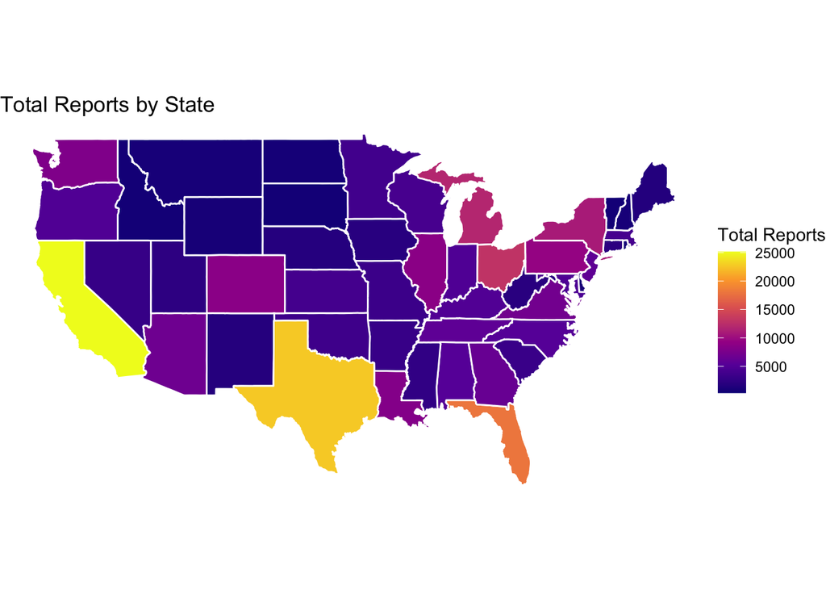

```r
ggplot(map_df_states, aes(x = long, y = lat, group = group, fill = total)) +
  geom_polygon(color = "white") +
  coord_fixed(1.3) +
  scale_fill_viridis_c(option = "plasma", na.value = "grey90") +
  labs(title = "Total Reports by State", fill = "Total Reports") +
  theme_void()
```

Next Steps:

- Plan to do traditional research to figure out ways to be able to track who and where these doctors are losing their license and traveling to another state.